# Méthodes d’apprentissage avancées

Daniel Pont

08/07/2020

# Méthodes d’apprentissage avancées

## 1. Méthodes basées sur les arbres de décision

### 1.1 Arbre de décision basique

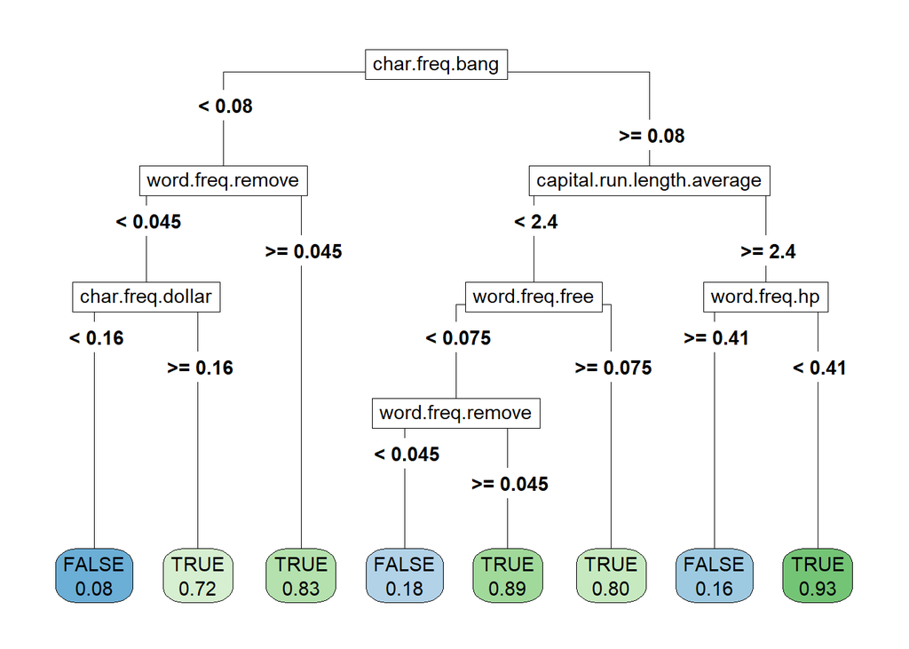

```r
spamD <- read.table('data/spamD.tsv', header = TRUE, sep = '\t')
spamD$isSpam <- spamD$spam == 'spam'
spamTrain <- subset(spamD, spamD$rgroup >= 10)
spamTest <- subset(spamD, spamD$rgroup < 10)

spamVars <- setdiff(colnames(spamD), list('rgroup', 'spam', 'isSpam'))

library(wrapr)

spamFormula <- mk_formula("isSpam", spamVars)

loglikelihood <- function(y, py) {
    pysmooth <- ifelse(py == 0, 1e-12,
    ifelse(py == 1, 1 - 1e-12, py))
      sum(y * log(pysmooth) + (1 - y) * log(1 - pysmooth))
}

accuracyMeasures <- function(pred, truth, name = "model") {
    dev.norm <- -2 * loglikelihood(as.numeric(truth), pred) / length(pred)
    ctable <- table(truth = truth,
    pred = (pred > 0.5))
    accuracy <- sum(diag(ctable)) / sum(ctable)
    precision <- ctable[2, 2] / sum(ctable[, 2])
    recall <- ctable[2, 2] / sum(ctable[2, ])
    f1 <- 2 * precision * recall / (precision + recall)
    data.frame(model = name, accuracy = accuracy, f1 = f1, dev.norm)
}

library(rpart)

treemodel <- rpart(spamFormula, spamTrain, method = "class")

library(rpart.plot)

rpart.plot(treemodel, type = 5, extra = 6)
```

```r
predTrain <- predict(treemodel, newdata = spamTrain)[, 2]
trainperf_tree <- accuracyMeasures(predTrain,
                  spamTrain$spam == "spam",
                  name = "tree, training")

predTest <- predict(treemodel, newdata = spamTest)[, 2]
testperf_tree <- accuracyMeasures(predTest,
                    spamTest$spam == "spam",
                    name = "tree, test")

library(pander)
panderOptions("plain.ascii", TRUE)
panderOptions("keep.trailing.zeros", TRUE)
panderOptions("table.style", "simple")
perf_justify <- "lrrr"
perftable <- rbind(trainperf_tree, testperf_tree)
pandoc.table(perftable, justify = perf_justify)
```

```
##
##
## model              accuracy       f1   dev.norm
## ---------------- ---------- -------- ----------
## tree, training       0.8996   0.8691     0.6304
## tree, test           0.8712   0.8280     0.7531
```

### 1.2 Bagging

Le bagging d’arbres de décision améliore la stabilité des modèles finaux en dilinuant la variance. Cela améliorela précision des prédictions. Le risque de surapprentissage avec le bagging est aussi moins élevé.

```r
ntrain <- dim(spamTrain)[1]
n <- ntrain
ntree <- 100

samples <- sapply(1:ntree,
                  FUN = function(iter)
                  { sample(1:ntrain, size = n, replace = TRUE) })

treelist <-lapply(1:ntree,
              FUN = function(iter) {
                  samp <- samples[, iter];
                  rpart(spamFormula, spamTrain[samp, ], method = "class") }
            )

predict.bag <- function(treelist, newdata) {
                preds <- sapply(1:length(treelist),
                              FUN = function(iter) {
                                predict(treelist[[iter]], newdata = newdata)[, 2] })
                                predsums <- rowSums(preds)
                                predsums / length(treelist)
}


pred <- predict.bag(treelist, newdata = spamTrain)

trainperf_bag <- accuracyMeasures(pred,
                    spamTrain$spam == "spam",
                    name = "bagging, training")

pred <- predict.bag(treelist, newdata = spamTest)

testperf_bag <- accuracyMeasures(pred,
                    spamTest$spam == "spam",
                    name = "bagging, test")

perftable <- rbind(trainperf_bag, testperf_bag)
pandoc.table(perftable, justify = perf_justify)
```

```
##
##
## model                 accuracy       f1   dev.norm
## ------------------- ---------- -------- ----------
## bagging, training       0.9141   0.8877     0.5067
## bagging, test           0.9039   0.8698     0.5690
```

### 1.3 Forêts aléatoires

La différence entre le bagging et les forêts aléatoires réside dans le fait que le bagging utilise l’ensemble des variables pour chaque arbre et pour chaque noeud.

Lors de la construction d’un noeud d’arbre dans une forêt aléatoire seule une fraction des variables (mtry) est utilisée. Cette approche permet dé décorréler les différents arbres. Ainsi si une partie des vraiables explicatives pose problème (en faussant les prédictions) ces variables ne se trouvent pas systématiquement dans tous les arbres.

```r
library(randomForest)
set.seed(5123512)

fmodel <- randomForest( x = spamTrain[, spamVars],
                        y = spamTrain$spam,
                        ntree = 100,
                        nodesize = 7,
                        importance = TRUE)

pred <- predict(fmodel,
                spamTrain[, spamVars],
                type = 'prob')[, 'spam']

trainperf_rf <- accuracyMeasures(predict(fmodel,
                                  newdata = spamTrain[, spamVars], type = 'prob')[, 'spam'],
                                  spamTrain$spam == "spam", name = "random forest, train")

testperf_rf <- accuracyMeasures(predict(fmodel,
                                  newdata
                                  = spamTest[, spamVars], type = 'prob')[, 'spam'],
                                  spamTest$spam == "spam", name = "random forest, test")

perftable <- rbind(trainperf_rf, testperf_rf)

pandoc.table(perftable, justify = perf_justify)
```

```
##
##
## model                    accuracy       f1   dev.norm
## ---------------------- ---------- -------- ----------
## random forest, train       0.9884   0.9852     0.1440
## random forest, test        0.9498   0.9341     0.3011
```

```r
trainf <- rbind(trainperf_tree, trainperf_bag, trainperf_rf)
                  pandoc.table(trainf, justify = perf_justify)
```

```
##
##
## model                    accuracy       f1   dev.norm
## ---------------------- ---------- -------- ----------
## tree, training             0.8996   0.8691     0.6304
## bagging, training          0.9141   0.8877     0.5067
## random forest, train       0.9884   0.9852     0.1440
```

```r
testf <- rbind(testperf_tree, testperf_bag, testperf_rf)
                pandoc.table(testf, justify = perf_justify)
```

```
##
##
## model                   accuracy       f1   dev.norm
## --------------------- ---------- -------- ----------
## tree, test                0.8712   0.8280     0.7531
## bagging, test             0.9039   0.8698     0.5690
## random forest, test       0.9498   0.9341     0.3011
```

```r
difff <- data.frame(model = c("tree", "bagging", "random forest"),
                  accuracy = trainf$accuracy - testf$accuracy,
                  f1 = trainf$f1 - testf$f1,
                  dev.norm = trainf$dev.norm - testf$dev.norm)

pandoc.table(difff, justify=perf_justify)
```

```
##
##
## model             accuracy        f1   dev.norm
## --------------- ---------- --------- ----------
## tree               0.02841   0.04111   -0.12275
## bagging            0.01014   0.01787   -0.06235
## random forest      0.03863   0.05110   -0.15711
```

```r
# importance des variables de la forêt aléatoire
varImp <- importance(fmodel)
varImp[1:10, ]
```

```
##                     non-spam      spam MeanDecreaseAccuracy MeanDecreaseGini
## word.freq.make      1.656795  3.432962             3.067899         8.131240
## word.freq.address   2.631231  3.800668             3.632077         9.971055
## word.freq.all       3.279517  6.235651             6.137927        27.744061
## word.freq.3d        3.900232  1.286917             3.753238         1.453879
## word.freq.our       9.966034 10.160010            12.039651        59.215337
## word.freq.over      4.657285  4.183888             4.894526        13.362416
## word.freq.remove   19.172764 14.020182            20.229958       158.008043
## word.freq.internet  7.595305  5.246213             8.036892        22.025964
## word.freq.order     3.167008  2.505777             3.065529         8.062485
## word.freq.mail      3.820764  2.786041             4.869502        11.605088
```

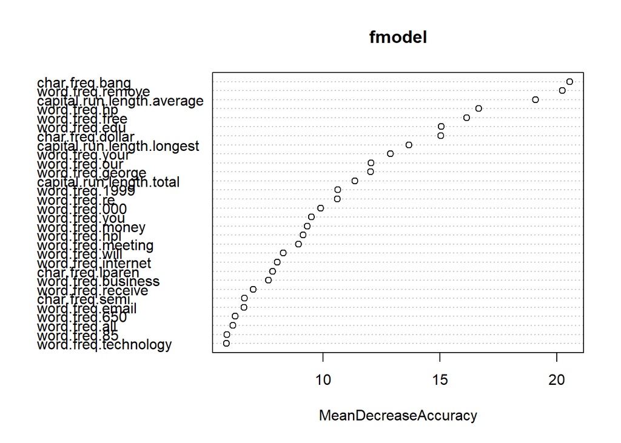

```r
varImpPlot(fmodel, type = 1)
```

```r
# Jeremy Howard (de Kaggle et de fast.ai fame) est un grand partisan du tri initial
# des variables par ordre d'importance pour ne garder que les plus pertinentes.
sorted <- sort(varImp[, "MeanDecreaseAccuracy"],
              decreasing = TRUE)
selVars <- names(sorted)[1:30]

fsel <- randomForest( x = spamTrain[, selVars],
                      y = spamTrain$spam,
                      ntree = 100,
                      nodesize = 7,
                      importance = TRUE)

trainperf_rf2 <- accuracyMeasures(predict(fsel,
                    newdata = spamTrain[, selVars], type = 'prob')[, 'spam'],
                    spamTrain$spam == "spam", name = "RF small, train")

testperf_rf2 <- accuracyMeasures(predict(fsel,
                    newdata=spamTest[, selVars], type = 'prob')[, 'spam'],
                    spamTest$spam == "spam", name = "RF small, test")

perftable <- rbind(testperf_rf, testperf_rf2)
pandoc.table(perftable, justify = perf_justify)
```

```
##
##
## model                   accuracy       f1   dev.norm
## --------------------- ---------- -------- ----------
## random forest, test       0.9498   0.9341     0.3011
## RF small, test            0.9520   0.9368     0.4000
```

> Attention : contrairement à une croyance répandue, il existe un risque de surapprentissage avec les forêts aléatoires : il n’est pas rare d’observer des prédictions extrêmement performantes sur les données d’aapprentisagge et nettement moins bonnes sur les données de test.

### 1.4 Gradient boosted trees

#### 1.4.1 Principe

Le principe de construction des gradient boosted trees est le suivant :

1. Utiliser l’ensemble d’arbres courant (TE) pour prédire la variable réponse sur les données d’apprentissage.
2. Mesurer l’erreur résiduelle entre les vraies valeurs et les valeurs pérdites
3. Ajuster un nouvel arbre T_i sur les résidus. Ajouter T_i à TE
4. Continuer jusqu’à la disparition des résidus ou à un autre critère d’arrêt.

#### 1.4.2 Exemple (dataset iris)

```r
# Chargement des données
iris <- iris
iris$class <- as.numeric(iris$Species == "setosa")
set.seed(2345)
intrain <- runif(nrow(iris)) < 0.75
train <- iris[intrain, ]
test <- iris[!intrain, ]
head(train)
```

```
##   Sepal.Length Sepal.Width Petal.Length Petal.Width Species class
## 1          5.1         3.5          1.4         0.2  setosa     1
## 2          4.9         3.0          1.4         0.2  setosa     1
## 3          4.7         3.2          1.3         0.2  setosa     1
## 4          4.6         3.1          1.5         0.2  setosa     1
## 5          5.0         3.6          1.4         0.2  setosa     1
## 6          5.4         3.9          1.7         0.4  setosa     1
```

```r
input <- as.matrix(train[, 1:4])
```

```r
# Validation croisée pour déterminer la taille du modèle (nbre d'arbres) optimale
library(xgboost)

cv <- xgb.cv(input,
  label = train$class,
  params = list(
    objective = "binary:logistic"
  ),
  nfold = 5,
  nrounds = 100,
  print_every_n = 10,
  metrics = "logloss")
evalframe <- as.data.frame(cv$evaluation_log)
head(evalframe)
```

```
##   iter train_logloss_mean train_logloss_std test_logloss_mean test_logloss_std
## 1    1          0.4547814      5.593782e-05         0.4549512      0.001252187
## 2    2          0.3175814      7.121685e-05         0.3177942      0.001570859
## 3    3          0.2294228      7.447523e-05         0.2296444      0.001636589
## 4    4          0.1696256      7.299753e-05         0.1698438      0.001609548
## 5    5          0.1277404      6.963505e-05         0.1279494      0.001543457
## 6    6          0.0977664      6.520307e-05         0.0979644      0.001459891
```

```r
(NROUNDS <- which.min(evalframe$test_logloss_mean))
```

```
## [1] 22
```

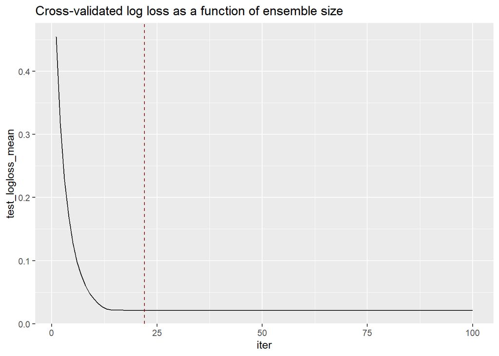

```r
library(ggplot2)

ggplot(evalframe, aes(x = iter, y = test_logloss_mean)) +
        geom_line() +
        geom_vline(xintercept = NROUNDS, color = "darkred", linetype = 2) +
        ggtitle("Cross-validated log loss as a function of ensemble size")
```

```r
# Apprentissage du modèle
model <- xgboost(data = input,
                  label = train$class,
                  params = list(
                      objective = "binary:logistic"
                  ),
                  nrounds = NROUNDS,
                  verbose = FALSE)

test_input <- as.matrix(test[, 1:4])
pred <- predict(model, test_input)

accuracyMeasures(pred, test$class)
```

```
##   model accuracy f1   dev.norm
## 1 model        1  1 0.03439622
```

#### 1.4.3 Classification de texte avec gadient-boosted trees

```r
# Chargement des données
library(zeallot)
c(texts, labels) %<-% readRDS("data/IMDBtrain.RDS")


# Méthodes utilitaires

library(wrapr)
library(xgboost)
# if this fails, make sure text2vec is installed:
# install.packages("text2vec")
library(text2vec)


#
# function that takes a training corpus (texts)
# and returns a vocabulary: 10,000 words that
# appear in at least 10% of the documents, but
# fewer than half.
#
create_pruned_vocabulary <- function(texts) {
  # create an iterator over the training set
  it_train <- itoken(texts,
                    preprocessor = tolower,
                    tokenizer = word_tokenizer,
                    ids = names(texts),
                    progressbar = FALSE)

  # tiny stop word list
  stop_words <- qc(the, a, an, this, that, those, i, you)
  vocab <- create_vocabulary(it_train, stopwords = stop_words)

  # prune the vocabulary
  # prune anything too common (appears in over half the documents)
  # prune anything too rare (appears in less than 0.1% of the documents)
  # limit to 10,000 words after that
  pruned_vocab <- prune_vocabulary(
    vocab,
    doc_proportion_max = 0.5,
    doc_proportion_min = 0.001,
    vocab_term_max = 10000
  )

  pruned_vocab
}


# take a corpus and a vocabulary
# and return a sparse matrix (of the kind xgboost will take)
# rows are documents, columns are vocab words
# this representation loses the order or the words in the documents
make_matrix <- function(texts, vocab) {
  iter <- itoken(texts,
                preprocessor = tolower,
                tokenizer = word_tokenizer,
                ids = names(texts),
                progressbar = FALSE)
  create_dtm(iter, vocab_vectorizer(vocab))
}

#
# Input:
# - dtm_train: document term matrix of class dgCmatrix
# - labelvvec: numeric vector of class labels (1 is positive class)
#
# Returns:
# - xgboost model
#
fit_imdb_model <- function(dtm_train, labels) {
  # run this estimate the number of rounds
  # needed for xgboost
  # cv <- xgb.cv(dtm_train, label = labels,
  #             params=list(
  #               objective="binary:logistic"
  #               ),
  #             nfold=5,
  #             nrounds=500,
  #             print_every_n=10,
  #             metrics="logloss")
  #
  # evalframe <- as.data.frame(cv$evaluation_log)
  # NROUNDS <- which.min(evalframe$test_logloss_mean)

  # we've run it already, so here's a good answer
  NROUNDS <- 371


  model <- xgboost(data=dtm_train, label=labels,
                  params=list(
                    objective="binary:logistic"
                  ),
                  nrounds=NROUNDS,
                  verbose=FALSE)

  model
}
```

```r
# création du vocabulaire et de la matrice termes-documents
vocab <- create_pruned_vocabulary(texts)
dtm_train <- make_matrix(texts, vocab)

# détermination du nombre d'arbres
cv <- xgb.cv(dtm_train,
              label = labels,
              params = list(
                  objective = "binary:logistic"
              ),
              nfold = 5,
              nrounds = 500,
              early_stopping_rounds = 20,
              print_every_n = 10,
              metrics = "logloss")
```

[output not shown]

```r
evalframe <- as.data.frame(cv$evaluation_log)
(NROUNDS <- which.min(evalframe$test_logloss_mean))
```

```
## [1] 335
```

```r
# création du modèle
model <- xgboost(data = dtm_train, label = labels,
                  params = list(
                  objective = "binary:logistic"
                ),
                nrounds = NROUNDS,
                verbose = FALSE)

pred = predict(model, dtm_train)
trainperf_xgb = accuracyMeasures(pred, labels, "training")

# Evaluation du modèle
c(test_texts, test_labels) %<-% readRDS("data/IMDBtest.RDS")
dtm_test = make_matrix(test_texts, vocab)
pred = predict(model, dtm_test)
testperf_xgb = accuracyMeasures(pred, test_labels, "test")
perftable <- rbind(trainperf_xgb, testperf_xgb)
pandoc.table(perftable, justify = perf_justify)
```

```
##
##
## model        accuracy       f1   dev.norm
## ---------- ---------- -------- ----------
## training       0.9908   0.9908     0.1661
## test           0.8716   0.8730     0.5950
```

#### 1.4.4 Utilisation de xgboost avec des variables catégorielles

Chargement des données :

```r
load("data/NatalBirthData.rData")
train <- sdata[sdata$ORIGRANDGROUP <= 5, ]
test <- sdata[sdata$ORIGRANDGROUP >5 , ]
input_vars <- setdiff(colnames(train), c("DBWT", "ORIGRANDGROUP"))
str(train[, input_vars])
```

```
## 'data.frame':    14386 obs. of  11 variables:
##  $ PWGT      : int  155 140 151 160 135 180 200 135 112 98 ...
##  $ WTGAIN    : int  42 40 1 47 25 20 24 51 36 22 ...
##  $ MAGER     : int  30 32 34 32 24 25 26 26 20 22 ...
##  $ UPREVIS   : int  14 13 15 1 4 10 14 15 14 10 ...
##  $ CIG_REC   : logi  FALSE FALSE FALSE TRUE FALSE FALSE ...
##  $ GESTREC3  : Factor w/ 2 levels ">= 37 weeks",..: 1 1 1 2 1 1 1 1 1 1 ...
##  $ DPLURAL   : Factor w/ 3 levels "single","triplet or higher",..: 1 1 1 1 1 1 1 1 1 1 ...
##  $ URF_DIAB  : logi  FALSE FALSE FALSE FALSE FALSE FALSE ...
##  $ URF_CHYPER: logi  FALSE FALSE FALSE FALSE FALSE FALSE ...
##  $ URF_PHYPER: logi  FALSE FALSE FALSE FALSE FALSE FALSE ...
##  $ URF_ECLAM : logi  FALSE FALSE FALSE FALSE FALSE FALSE ...
```

Pré-traitement avec vtreat :

```r
library(vtreat)

# Creates clean numeric variables, (“clean”),
#         missingness indicators, (“isBad”),
#         indicator variables (“lev”),
#         but not catP (prevalence) variables
treatplan <- designTreatmentsZ(train,
                                input_vars,
                                codeRestriction = c("clean", "isBAD", "lev" ),
                                verbose = FALSE)

train_treated <- prepare(treatplan, train)
str(train_treated)
```

```
## 'data.frame':    14386 obs. of  14 variables:
##  $ PWGT                           : num  155 140 151 160 135 180 200 135 112 98 ...
##  $ WTGAIN                         : num  42 40 1 47 25 20 24 51 36 22 ...
##  $ MAGER                          : num  30 32 34 32 24 25 26 26 20 22 ...
##  $ UPREVIS                        : num  14 13 15 1 4 10 14 15 14 10 ...
##  $ CIG_REC                        : num  0 0 0 1 0 0 0 0 0 0 ...
##  $ URF_DIAB                       : num  0 0 0 0 0 0 0 0 0 0 ...
##  $ URF_CHYPER                     : num  0 0 0 0 0 0 0 0 0 0 ...
##  $ URF_PHYPER                     : num  0 0 0 0 0 0 0 0 0 0 ...
##  $ URF_ECLAM                      : num  0 0 0 0 0 0 0 0 0 0 ...
##  $ GESTREC3_lev_x_lt_37_weeks     : num  0 0 0 1 0 0 0 0 0 0 ...
##  $ GESTREC3_lev_x_gt_eq_37_weeks  : num  1 1 1 0 1 1 1 1 1 1 ...
##  $ DPLURAL_lev_x_single           : num  1 1 1 1 1 1 1 1 1 1 ...
##  $ DPLURAL_lev_x_triplet_or_higher: num  0 0 0 0 0 0 0 0 0 0 ...
##  $ DPLURAL_lev_x_twin             : num  0 0 0 0 0 0 0 0 0 0 ...
```

Création et application du modèle :

```r
birthwt_model <- xgboost(as.matrix(train_treated),
                            train$DBWT,
                            params = list(
                                objective = "reg:linear",
                                base_score = mean(train$DBWT)
                            ),
                            nrounds = 50,
                            verbose = FALSE)
```

```
## [16:48:26] WARNING: amalgamation/../src/objective/regression_obj.cu:170: reg:linear is now deprecated in favor of reg:squarederror.
```

```r
test_treated <- prepare(treatplan, test)
pred <- predict(birthwt_model, as.matrix(test_treated))
```

## 2. GAM (Generalized Additive Model - modèle additif généralisé)

### 2.1 Principe

Un modèle linéaire est de la forme suivante :

f(x[i, ]) = b0 + b[1] * x[i, 1] + b[2] * x[i, 2] + … b[n] * x[i, n]

Dans sa forme la plus simple, un modèle GAM assouplit la contrainte de linéarité et trouve un ensemble de fonctions s_i () (et un terme constant a0) tels que :

f(x[i,]) = a0 + s_1(x[i, 1]) + s_2(x[i, 2]) + … s_n(x[i, n])

Nous voulons également que f (x [i,]) soit aussi proche de y [i] que possible. Les fonctions s_i () sont des ajustements de courbes lisses construits à partir de polynômes. Les courbes sont appelées splines et sont conçues pour passer le plus près possible des données sans surajustement.

### 2.2 Exemple de régression à une dimension

#### 2.2.1 Création d’un jeu de données artificielles

```r
set.seed(602957)
x <- rnorm(1000)
noise <- rnorm(1000, sd = 1.5)
y <- 3 * sin(2 * x) + cos(0.75 * x) - 1.5 * (x^2) + noise
select <- runif(1000)
frame <- data.frame(y = y, x = x)
train <- frame[select > 0.1, ]
test <- frame[select <= 0.1, ]
```

#### 2.2.2 Régression linéaire sur les données artificielles

```r
lin_model <- lm(y ~ x, data = train)
summary(lin_model)
```

```
##
## Call:
## lm(formula = y ~ x, data = train)
##
## Residuals:
##     Min      1Q  Median      3Q     Max
## -17.698  -1.774   0.193   2.499   7.529
##
## Coefficients:
##             Estimate Std. Error t value Pr(>|t|)
## (Intercept)  -0.8330     0.1161  -7.175 1.51e-12 ***
## x             0.7395     0.1197   6.180 9.74e-10 ***
## ---
## Signif. codes:  0 '***' 0.001 '**' 0.01 '*' 0.05 '.' 0.1 ' ' 1
##
## Residual standard error: 3.485 on 899 degrees of freedom
## Multiple R-squared:  0.04075,    Adjusted R-squared:  0.03968
## F-statistic: 38.19 on 1 and 899 DF,  p-value: 9.737e-10
```

```r
rmse <- function(residuals) {
  sqrt(mean(residuals^2))
}

train$pred_lin <- predict(lin_model, train)
resid_lin <- with(train, y - pred_lin)
rmse(resid_lin)
```

```
## [1] 3.481091
```

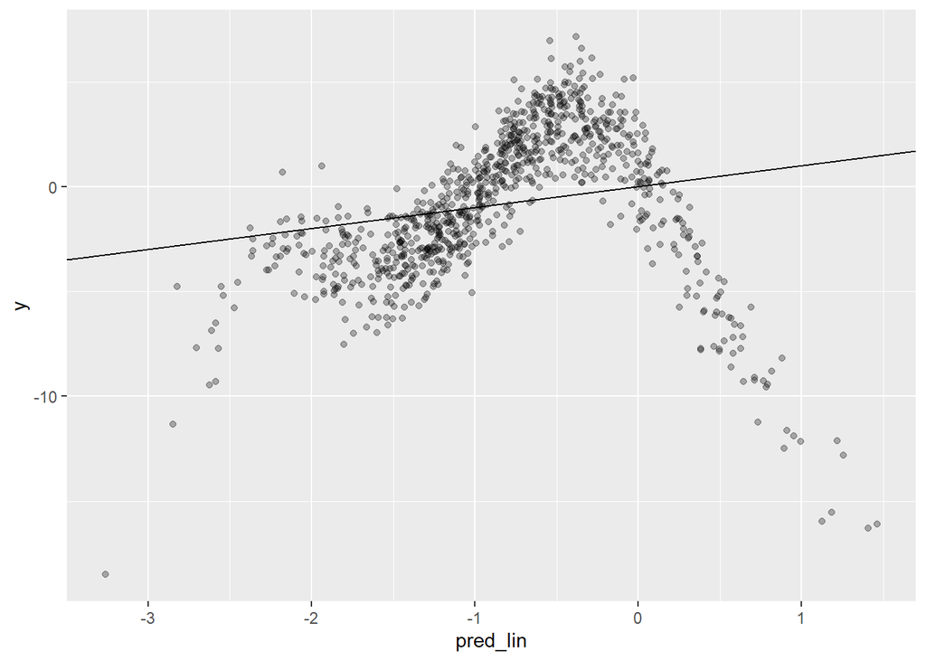

```r
library(ggplot2)
ggplot(train, aes(x = pred_lin, y = y)) +
              geom_point(alpha = 0.3) +
              geom_abline()
```

#### 2.2.3 Application de GAM sur les données artificielles

```r
library(mgcv)

gam_model <- gam(y ~ s(x), data = train)
gam_model$converged
```

```
## [1] TRUE
```

```r
summary(gam_model)
```

```
##
## Family: gaussian
## Link function: identity
##
## Formula:
## y ~ s(x)
##
## Parametric coefficients:
##             Estimate Std. Error t value Pr(>|t|)
## (Intercept) -0.83467    0.04852   -17.2   <2e-16 ***
## ---
## Signif. codes:  0 '***' 0.001 '**' 0.01 '*' 0.05 '.' 0.1 ' ' 1
##
## Approximate significance of smooth terms:
##        edf Ref.df     F p-value
## s(x) 8.685  8.972 497.4  <2e-16 ***
## ---
## Signif. codes:  0 '***' 0.001 '**' 0.01 '*' 0.05 '.' 0.1 ' ' 1
##
## R-sq.(adj) =  0.832   Deviance explained = 83.4%
## GCV =  2.144  Scale est. = 2.121     n = 901
```

```r
train$pred <- predict(gam_model, train)
resid_gam <- with(train, y - pred)
rmse(resid_gam)
```

```
## [1] 1.448514
```

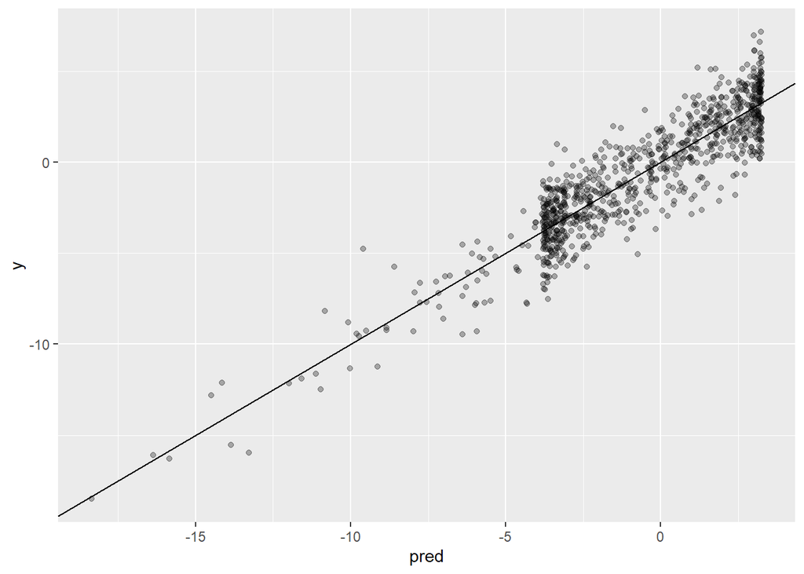

```r
ggplot(train, aes(x = pred, y = y)) +
geom_point(alpha = 0.3) +
geom_abline()
```

#### 2.2.4 Comparaison des performances entre GAM et la régression linéaire

```r
test <- transform(test,
pred_lin = predict(lin_model, test),
pred_gam = predict(gam_model, test) )
test <- transform(test,
resid_lin = y - pred_lin,
resid_gam = y - pred_gam)

rmse(test$resid_lin)
```

```
## [1] 2.792653
```

```r
rmse(test$resid_gam)
```

```
## [1] 1.401399
```

```r
library(sigr)
wrapFTest(test, "pred_lin", "y")$R2
```

```
## [1] 0.115395
```

```r
wrapFTest(test, "pred_gam", "y")$R2
```

```
## [1] 0.777239
```

#### 2.2.5 Extraction de la fonction de spline du modèle GAM

```r
sx <- predict(gam_model, type = "terms")
summary(sx)
```

```
##       s(x)
##  Min.   :-17.527035
##  1st Qu.: -2.378636
##  Median :  0.009427
##  Mean   :  0.000000
##  3rd Qu.:  2.869166
##  Max.   :  4.084999
```

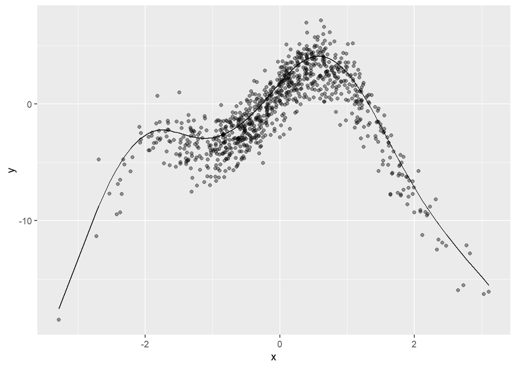

```r
xframe <- cbind(train, sx = sx[,1])

ggplot(xframe, aes(x = x)) +
  geom_point(aes(y = y), alpha = 0.4) +
  geom_line(aes(y = sx))
```

#### 2.2.6 Utilisation de GAM sur des données réelles

Pour référence, application d’une régression linéaire :

```r
library(mgcv)
library(ggplot2)
load("data/NatalBirthData.rData")
train <- sdata[sdata$ORIGRANDGROUP <= 5, ]
test <- sdata[sdata$ORIGRANDGROUP > 5, ]
form_lin <- as.formula("DBWT ~ PWGT + WTGAIN + MAGER + UPREVIS")
linmodel <- lm(form_lin, data = train)
summary(linmodel)
```

```
##
## Call:
## lm(formula = form_lin, data = train)
##
## Residuals:
##      Min       1Q   Median       3Q      Max
## -3155.43  -272.09    45.04   349.81  2870.55
##
## Coefficients:
##              Estimate Std. Error t value Pr(>|t|)
## (Intercept) 2419.7090    31.9291  75.784  < 2e-16 ***
## PWGT           2.1713     0.1241  17.494  < 2e-16 ***
## WTGAIN         7.5773     0.3178  23.840  < 2e-16 ***
## MAGER          5.3213     0.7787   6.834  8.6e-12 ***
## UPREVIS       12.8753     1.1786  10.924  < 2e-16 ***
## ---
## Signif. codes:  0 '***' 0.001 '**' 0.01 '*' 0.05 '.' 0.1 ' ' 1
##
## Residual standard error: 562.7 on 14381 degrees of freedom
## Multiple R-squared:  0.06596,    Adjusted R-squared:  0.0657
## F-statistic: 253.9 on 4 and 14381 DF,  p-value: < 2.2e-16
```

Création d’un modèle GAM :

```r
form_gam <- as.formula("DBWT ~ s(PWGT) + s(WTGAIN) +
s(MAGER) + s(UPREVIS)")
gammodel <- gam(form_gam, data = train)
gammodel$converged
```

```
## [1] TRUE
```

```r
## [1] TRUE
summary(gammodel)
```

```
##
## Family: gaussian
## Link function: identity
##
## Formula:
## DBWT ~ s(PWGT) + s(WTGAIN) + s(MAGER) + s(UPREVIS)
##
## Parametric coefficients:
##             Estimate Std. Error t value Pr(>|t|)
## (Intercept) 3276.948      4.623   708.8   <2e-16 ***
## ---
## Signif. codes:  0 '***' 0.001 '**' 0.01 '*' 0.05 '.' 0.1 ' ' 1
##
## Approximate significance of smooth terms:
##              edf Ref.df       F  p-value
## s(PWGT)    5.374  6.443  69.010  < 2e-16 ***
## s(WTGAIN)  4.719  5.743 102.313  < 2e-16 ***
## s(MAGER)   7.742  8.428   7.145 1.37e-09 ***
## s(UPREVIS) 5.491  6.425  48.423  < 2e-16 ***
## ---
## Signif. codes:  0 '***' 0.001 '**' 0.01 '*' 0.05 '.' 0.1 ' ' 1
##
## R-sq.(adj) =  0.0927   Deviance explained = 9.42%
## GCV = 3.0804e+05  Scale est. = 3.0752e+05  n = 14386
```

Le GAM a amélioré l’ajustement, et les quatre variables semblent avoir une relation non linéaire avec le poids de naissance, comme en témoignent les edfs (estimated degrees of freedom) tous supérieurs à 1. Nous pourrions utiliser plot (gammodel) pour examiner la forme des fonctions s (); comparons-les plutôt avec une courbe de lissage directe de chaque variable par rapport au poids de la mère.

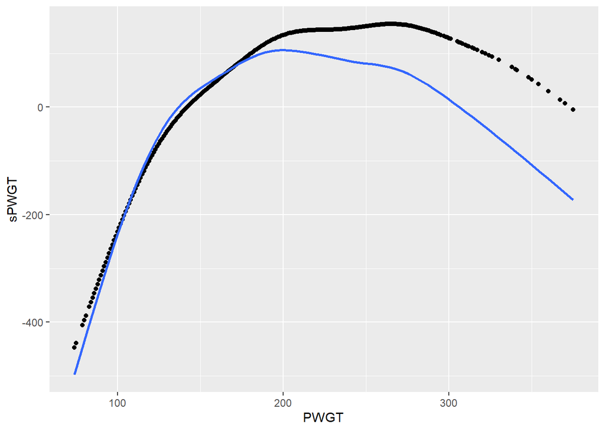

```r
# Gets the matrix of s() functions
terms <- predict(gammodel, type = "terms")
# Binds in the birth weight (DBWT)
terms <- cbind(DBWT = train$DBWT, terms)
# Shifts all the columns to be zero mean (to make comparisons easy); converts to a data frame
tframe <- as.data.frame(scale(terms, scale = FALSE))
# Makes the column names referencefriendly (s(PWGT) is converted to sPWGT, etc.)
colnames(tframe) <- gsub('[()]', '', colnames(tframe))
# Binds in the input variables
vars = c("PWGT", "WTGAIN", "MAGER", "UPREVIS")

pframe <- cbind(tframe, train[, vars])

# Compares the spline s(PWGT) to the smoothed curve of DBWT (baby’s weight)
# as a function of mother’s weight (PWGT)
ggplot(pframe, aes(PWGT)) +
  geom_point(aes(y = sPWGT)) +
  geom_smooth(aes(y = DBWT), se = FALSE)
```

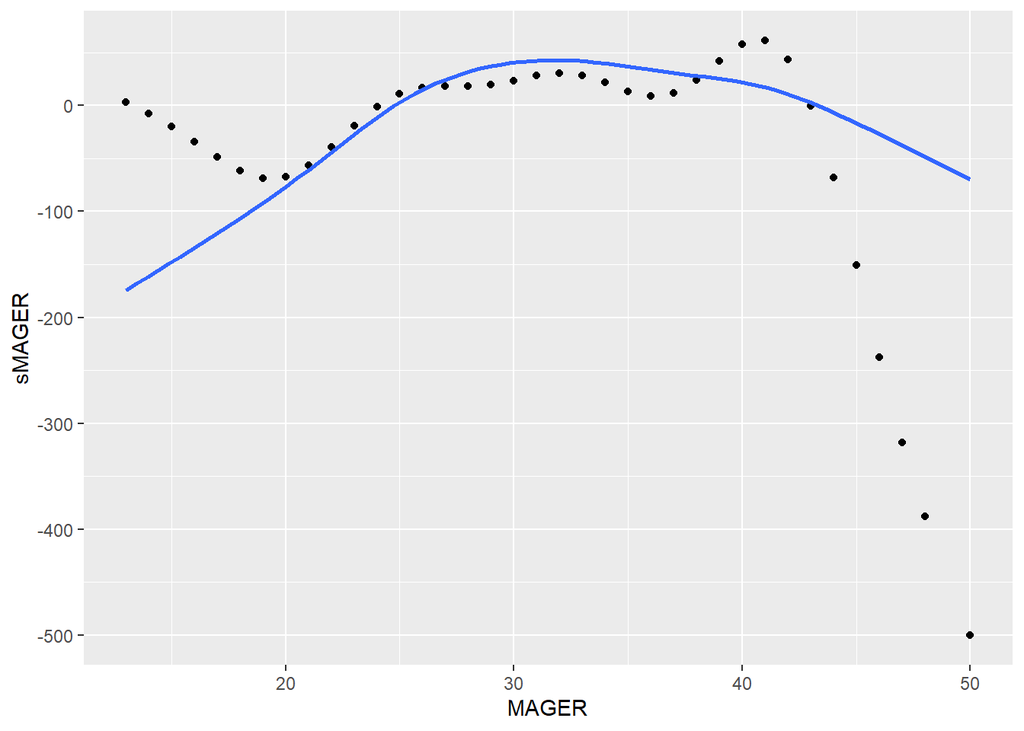

```r
ggplot(pframe, aes(MAGER)) +
  geom_point(aes(y = sMAGER)) +
  geom_smooth(aes(y = DBWT), se = FALSE)
```

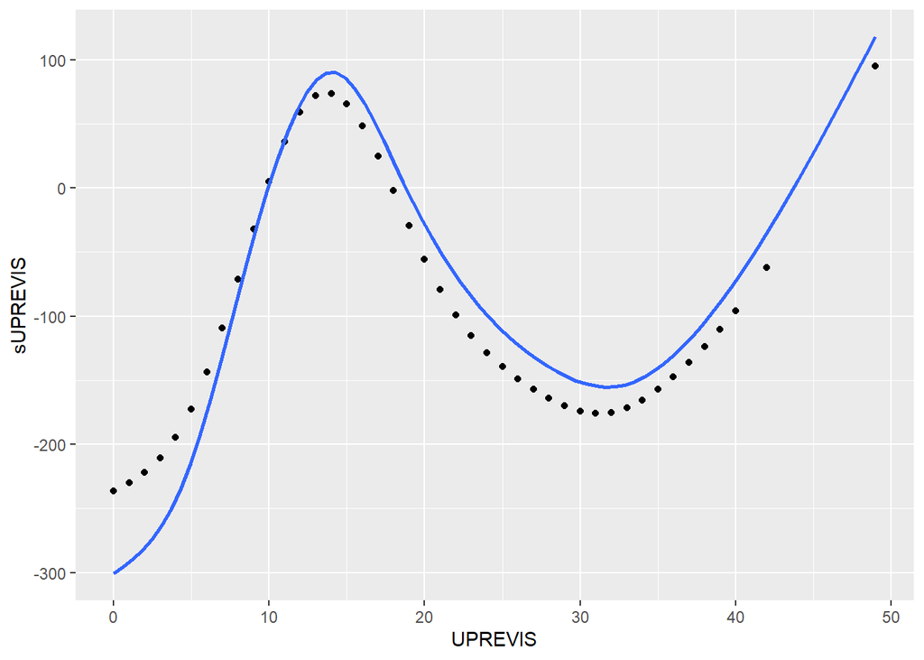

```r
ggplot(pframe, aes(UPREVIS)) +
  geom_point(aes(y = sUPREVIS)) +
  geom_smooth(aes(y = DBWT), se = FALSE)
```

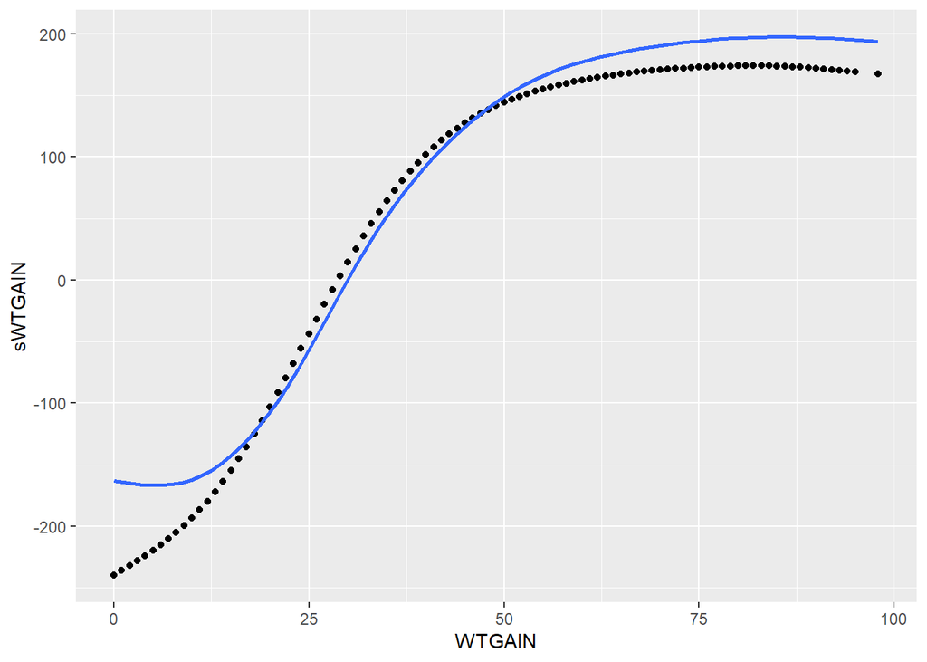

```r
ggplot(pframe, aes(WTGAIN)) +
  geom_point(aes(y = sWTGAIN)) +
  geom_smooth(aes(y = DBWT), se = FALSE)
```

#### 2.2.7 Régression logistique avec GAM

Pour référence, considérons une régression logistique avec GLM :

```r
form <- as.formula("DBWT < 2000 ~ PWGT + WTGAIN + MAGER + UPREVIS")
logmod <- glm(form, data = train, family = binomial(link = "logit"))
```

Avec GAM, la régression logistique devient :

```r
form2 <- as.formula("DBWT < 2000 ~ s(PWGT) + s(WTGAIN) + s(MAGER) + s(UPREVIS)")
glogmod <- gam(form2, data = train, family = binomial(link = "logit"))

glogmod$converged
```

```
## [1] TRUE
```

```r
summary(glogmod)
```

```
##
## Family: binomial
## Link function: logit
##
## Formula:
## DBWT < 2000 ~ s(PWGT) + s(WTGAIN) + s(MAGER) + s(UPREVIS)
##
## Parametric coefficients:
##             Estimate Std. Error z value Pr(>|z|)
## (Intercept) -3.94085    0.06794     -58   <2e-16 ***
## ---
## Signif. codes:  0 '***' 0.001 '**' 0.01 '*' 0.05 '.' 0.1 ' ' 1
##
## Approximate significance of smooth terms:
##              edf Ref.df  Chi.sq  p-value
## s(PWGT)    1.905  2.420   2.463  0.39023
## s(WTGAIN)  3.674  4.543  64.211 1.81e-12 ***
## s(MAGER)   1.003  1.005   8.347  0.00393 **
## s(UPREVIS) 6.802  7.216 217.631  < 2e-16 ***
## ---
## Signif. codes:  0 '***' 0.001 '**' 0.01 '*' 0.05 '.' 0.1 ' ' 1
##
## R-sq.(adj) =  0.0331   Deviance explained = 9.14%
## UBRE = -0.76987  Scale est. = 1         n = 14386
```

### 2.3 Résoudre des problèmes non linéairement séparables avec SVM

#### 2.3.1 Exemples d’utilisation de SVM (données “spirale”)

Repréesentation graphique des données :

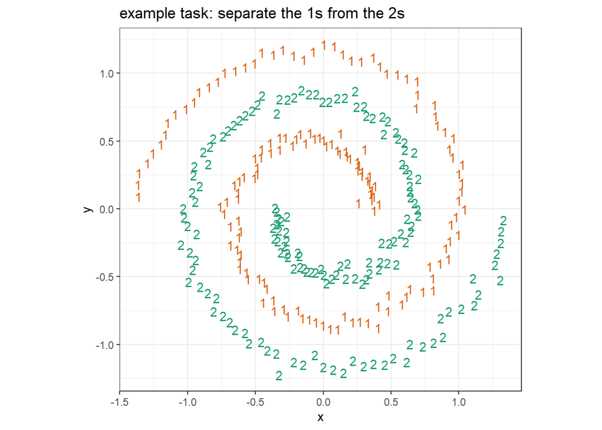

```r
library(kernlab)
data(spirals)
sc <- specc(spirals, centers = 2)
s <- data.frame(x = spirals[, 1], y = spirals[, 2],
class = as.factor(sc))

library('ggplot2')
ggplot(data = s) +
geom_text(aes(x = x, y = y,
label = class, color = class)) +
scale_color_manual(values = c("#d95f02", "#1b9e77")) +
coord_fixed() +
theme_bw() +
theme(legend.position = 'none') +
ggtitle("example task: separate the 1s from the 2s")
```

**Utilisation de SVM avec un noyau simpliste (linéaire), mal adapté :**

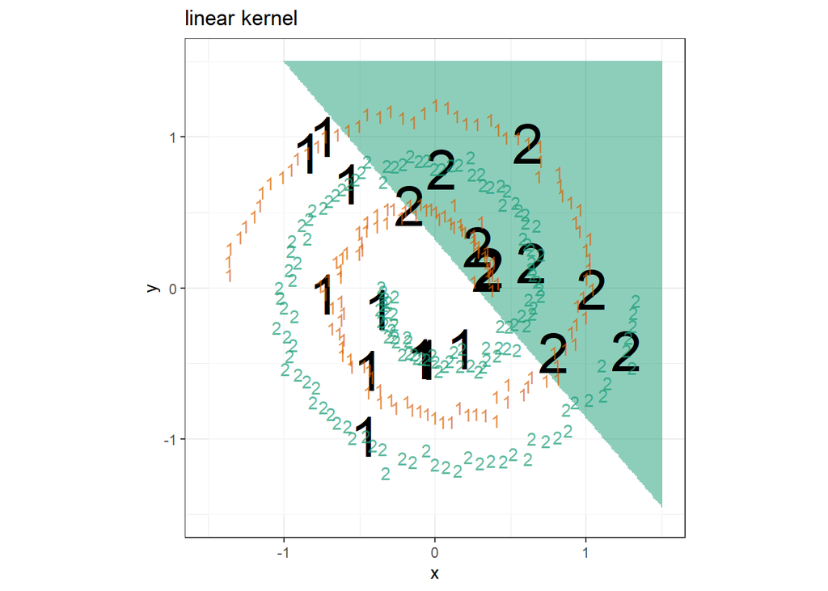

```r
set.seed(2335246L)
s$group <- sample.int(100, size = dim(s)[[1]], replace = TRUE)
sTrain <- subset(s, group > 10)
sTest <- subset(s,group <= 10)

library('e1071')
mSVMV <- svm(class ~ x + y, data = sTrain, kernel = 'linear', type =
'nu-classification')
sTest$predSVMV <- predict(mSVMV, newdata = sTest, type = 'response')
shading <- expand.grid(
x = seq(-1.5, 1.5, by = 0.01),
y = seq(-1.5, 1.5, by = 0.01))
shading$predSVMV <- predict(mSVMV, newdata = shading, type = 'response')

ggplot(mapping = aes(x = x, y = y)) +
    geom_tile(data = shading, aes(fill = predSVMV),
    show.legend = FALSE, alpha = 0.5) +
    scale_color_manual(values = c("#d95f02", "#1b9e77")) +
    scale_fill_manual(values = c("white", "#1b9e77")) +
    geom_text(data = sTest, aes(label = predSVMV), size = 12) +
    geom_text(data = s, aes(label = class, color = class),
    alpha = 0.7) +
    coord_fixed() +
    theme_bw() +
    theme(legend.position = 'none') +
    ggtitle("linear kernel")
```

**SVM avec un noyau adpaté (Radial/Gaussian) :**

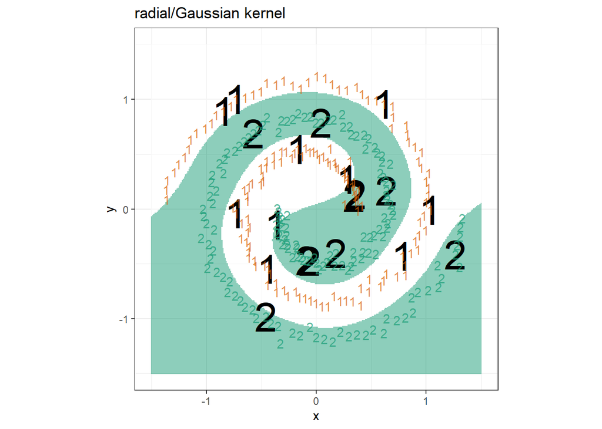

```r
mSVMG <- svm(class ~ x + y, data = sTrain, kernel = 'radial', type = 'nu-classification')

sTest$predSVMG <- predict(mSVMG, newdata = sTest, type = 'response')

shading <- expand.grid(
              x = seq(-1.5, 1.5, by = 0.01),
              y = seq(-1.5, 1.5, by = 0.01))
              shading$predSVMG <- predict(mSVMG, newdata = shading, type = 'response')
              ggplot(mapping = aes(x = x, y = y)) +
              geom_tile(data = shading, aes(fill = predSVMG),
              show.legend = FALSE, alpha = 0.5) +
              scale_color_manual(values = c("#d95f02", "#1b9e77")) +
              scale_fill_manual(values = c("white", "#1b9e77")) +
              geom_text(data = sTest, aes(label = predSVMG),
              size = 12) +
              geom_text(data = s,aes(label = class, color = class), alpha = 0.7) +
              coord_fixed() +
              theme_bw() +
              theme(legend.position = 'none') +
              ggtitle("radial/Gaussian kernel")
```

#### 2.3.2 Comprendre SVM

Un SVM trouve une fonction de décision linéaire (déterminée par les paramètres w et b), où pour un exemple donné x la machine décide que :

- si w% *% phi (x) + b> = 0 x est dans la classe
- sinon x n’est pas dans la classe sinon

Le modèle est entièrement déterminé par la fonction phi (), le vecteur w et le décalage scalaire b.

L’idée est que phi () déplace les données dans un espace où les classes sont séparables linéairement.

SVM trouve alors une frontière linéaire (représentée par w et b) séparant les deux classes de données dans ce nouvel espace .

Le modèle w, b est idéalement choisi de sorte que

- w %*% phi (x) + b> = u pour tous les x dans la classe d’intérêt,
- w%*% phi (x) + b <= v pour les autres x

Les données sont appelées séparables si u> v. La taille de la séparation est (u - v) / sqrt (w% *% w) et est appelée la marge. L’objectif de SVM est de maximiser la marge.

Cette limite linéaire dans l’espace d’arrivée peut être incurvée dans l’espace d’origine.

#### 2.3.3 Comprendre l’astuce du noyau

Soit u et v deux variables.  
Une fonction k (,)est appelée fonction de noyau si et seulement s’il existe une fonction phi () tel que k (u, v ) = phi (u)%*% phi (v) pour tous les u, v. k (u, v) = phi (u)%* % phi (v) est l’expansion Mercer du noyau. (en référence au théorème de Mercer; voir http://mng.bz/xFD2) )

```r
# Exemple (artificiel) de noyau

u <- c(1, 2)
v <- c(3, 4)

k <- function(u, v) {
  u[1] * v[1] +
  u[2] * v[2] +
  u[1] * u[1] * v[1] * v[1] +
  u[2] * u[2] * v[2] * v[2] +
  u[1] * u[2] * v[1] * v[2]
}

phi <- function(x) {
  x <- as.numeric(x)
  c(x, x*x, combn(x, 2, FUN = prod))
}

print(k(u, v))
```

```
## [1] 108
```

```r
print(phi(u))
```

```
## [1] 1 2 1 4 2
```

```r
print(phi(v))
```

```
## [1]  3  4  9 16 12
```

```r
print(as.numeric(phi(u) %*% phi(v)))
```

```
## [1] 108
```